# BMIN503/EPID600 Final Project_QIAN

Sally Qian

Use this template to complete your project throughout the course. Your Final Project presentation will be based on the contents of this document. Replace the title/name above and text below with your own, but keep the headers.

> 1. Introduction

> Obesity is described as an adverse effect on human health caused by accumulated excess body fat. As one of the major health problems in US, obesity enhances the risk of various severe diseases such as coronary artery disease, high blood pressure, and type 2 diabetes. According to reported data from Centers for Disease Control and Prevention (CDC), the prevalence of obesity increased from 30.5% to 42.4% in the past two decades. Also, the huge medical cost made obesity become a more common and serious disease. Researchers and physicians are always looking for a more effective method to alleviate the problem of obesity. In addition, obesity affects some groups more than others and multiple factors including ethnicity, gender and economic status would have impact on individuals’ vulnerability to obesity. Therefore, this study aims to explore how effective the moderate behavioral weight loss program (intervention group) in overweight and obese adults from the general population, compared with the low-intensity version of the program (control condition). Multiple variables, including clinical site, gender, ethnicity and so on, were recorded and statistically analyzed to determine their impacts on the effectiveness of the moderate behavioral weight loss program.
> 2. Data description

> 261 subjects were recruited in total, 166 of them having complete data record were analyzed. Each subject was randoized into either moderate or low intensity weight-loss program, where the body weights before and after the treatment were documented. The primary outcome for this proect was the change of patients’ body weight before and after the treatments, and the secondary outcome was whether the patients had reduced at least 5% bpdy weight due to the weight-loss program Major covariates that will be examined include clinical site, duration of treatment, height, age, gender, race, number of comorbid conditions related to obesity, education, marital status, and tobacco and alcohol use.

```r
library(DescTools)
library(readxl)
library(MASS)
library(olsrr)
# Load data
WgtLoss_data <- read_excel("E:/Dropbox/School/Fall 2021/BMIN 503/Final Project/WeightLossData.xlsx")

# 2. Data Description---------------------------------------------
### Find how many data entry are complete (exclude rows with NA)
is_complete <- !is.na(WgtLoss_data$month) & !is.na(WgtLoss_data$wgt_final)
num_complete_data <- sum(is_complete)
print(sprintf("Number of complete data = %d", num_complete_data))
```

```
## [1] "Number of complete data = 166"
```

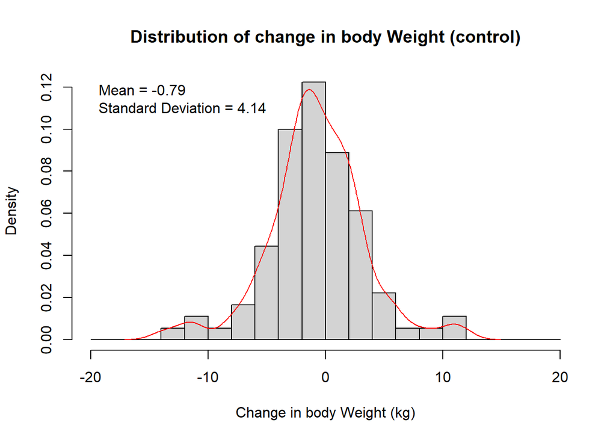

```r
clean_WL_data <- WgtLoss_data[complete.cases(WgtLoss_data),]

# 2.1 Distribution of change in body weight
### Control group
ctrl_WL_data <- clean_WL_data[(clean_WL_data$tx == 0),]
ctrl_wgt_loss <- (ctrl_WL_data$wgt_final - ctrl_WL_data$wgt_base)
hist(ctrl_wgt_loss,
     main = "Distribution of change in body Weight (control)",
     xlab = "Change in body Weight (kg)",
     freq = FALSE,
     breaks = seq(-20, 20, 2))
lines(
  x = density(x = ctrl_wgt_loss),
  col = "red"
)

legend(
  "topleft",
  legend = c(paste("Mean =", round(mean(ctrl_wgt_loss), 2)),
             paste("Standard Deviation =", round(sd(ctrl_wgt_loss), 2))),
  cex = 1, bty = "n"
)
```

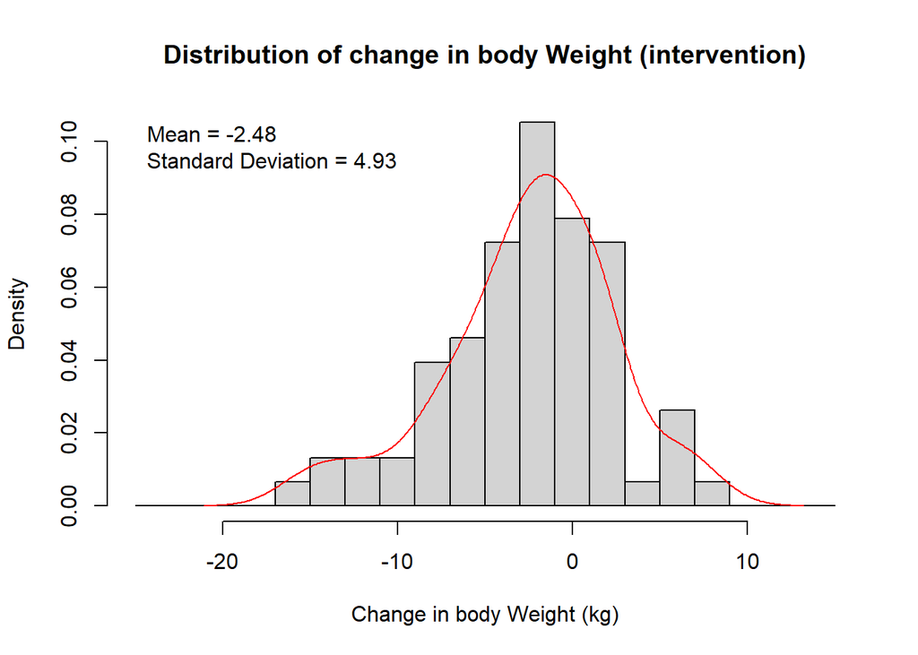

```r
# Intervention group
int_WL_data <- clean_WL_data[(clean_WL_data$tx == 1), ]
int_wgt_loss <- (int_WL_data$wgt_final - int_WL_data$wgt_base)
hist(int_wgt_loss,
     main = "Distribution of change in body Weight (intervention)",
     xlab = "Change in body Weight (kg)",
     freq = FALSE,
     breaks = seq(-25, 15, 2))
lines(
  x = density(x = int_wgt_loss),
  col = "red"
)
legend(
  "topleft",
  legend = c(paste("Mean =", round(mean(int_wgt_loss), 2)),
             paste("Standard Deviation =", round(sd(int_wgt_loss), 2))),
  cex = 1, bty = "n"
)
```

```r
### Proportion of subject having reduced at least 5% body-weight after the program
# Percentage change in body weight
WL_percent <- (clean_WL_data$wgt_final - clean_WL_data$wgt_base) / (clean_WL_data$wgt_base)
# control group
p_ctrl <- (sum(WL_percent <= -0.05 & clean_WL_data$tx == 0))/ length(ctrl_wgt_loss)
print(sprintf("Proportion of subjects having reduced at least five-percent body-weight (control) = %f", p_ctrl))
```

```
## [1] "Proportion of subjects having reduced at least five-percent body-weight (control) = 0.111111"
```

```r
# Intervention group
p_int <- (sum(WL_percent <= -0.05 & clean_WL_data$tx == 1))/ length(int_wgt_loss)
print(sprintf("Proportion of subjects having reduced at least five-percent body-weight (intervention) = %f", p_int))
```

```
## [1] "Proportion of subjects having reduced at least five-percent body-weight (intervention) = 0.250000"
```

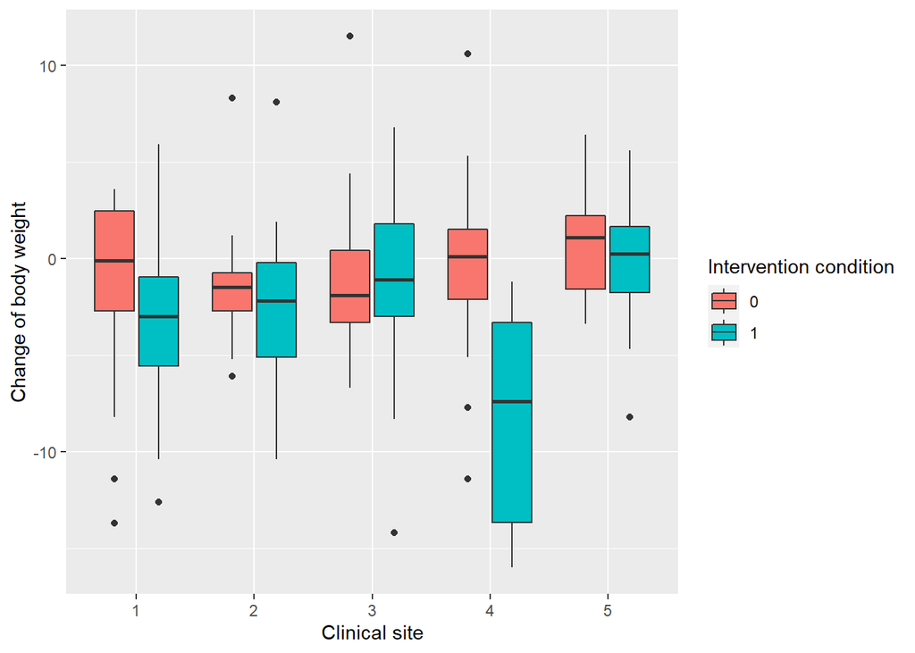

```r
library(ggplot2)

### 2.2 Visualize the weight loss data by different covariate groups
## 2.2.1 Catagorical covariates

## Clinical site
boxplot_ClinicSite <- ggplot(data = clean_WL_data,
                  mapping = aes (x = as.factor(site), y = (wgt_final - wgt_base), fill = as.factor(tx)))+
  geom_boxplot() +
  xlab("Clinical site") +
  ylab("Change of body weight") +
  scale_fill_discrete("Intervention condition")
plot(boxplot_ClinicSite)
```

```r
num_s1 <- sum(clean_WL_data$site == 1)
num_s2 <- sum(clean_WL_data$site == 2)
num_s3 <- sum(clean_WL_data$site == 3)
num_s4 <- sum(clean_WL_data$site == 4)
num_s5 <- sum(clean_WL_data$site == 5)
print(sprintf("Number of subjects in clinical site 1 = %d, site 2 = %d, site 3 = %d, site 4 = %d, site 5 = %d", num_s1, num_s2, num_s3, num_s4, num_s5))
```

```
## [1] "Number of subjects in clinical site 1 = 38, site 2 = 44, site 3 = 40, site 4 = 20, site 5 = 24"
```

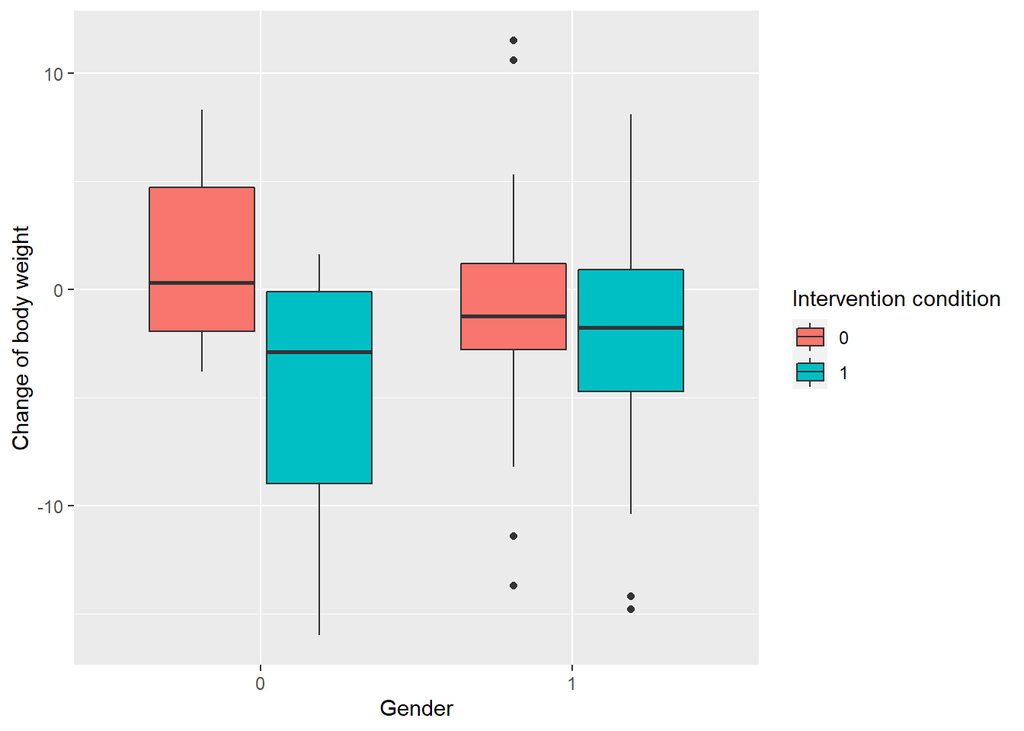

```r
## Gender
boxplot_Gender <- ggplot(data = clean_WL_data,
                  mapping = aes (x = as.factor(gender), y = (wgt_final - wgt_base), fill = as.factor(tx)))+
  geom_boxplot() +
  xlab("Gender") +
  ylab("Change of body weight") +
  scale_fill_discrete("Intervention condition")
plot(boxplot_Gender)
```

```r
num_male <- sum(clean_WL_data$gender == 0)
num_female <- sum(clean_WL_data$gender == 1)
print(sprintf("Number of male subjects = %d, female subjects= %d", num_male, num_female))
```

```
## [1] "Number of male subjects = 26, female subjects= 140"
```

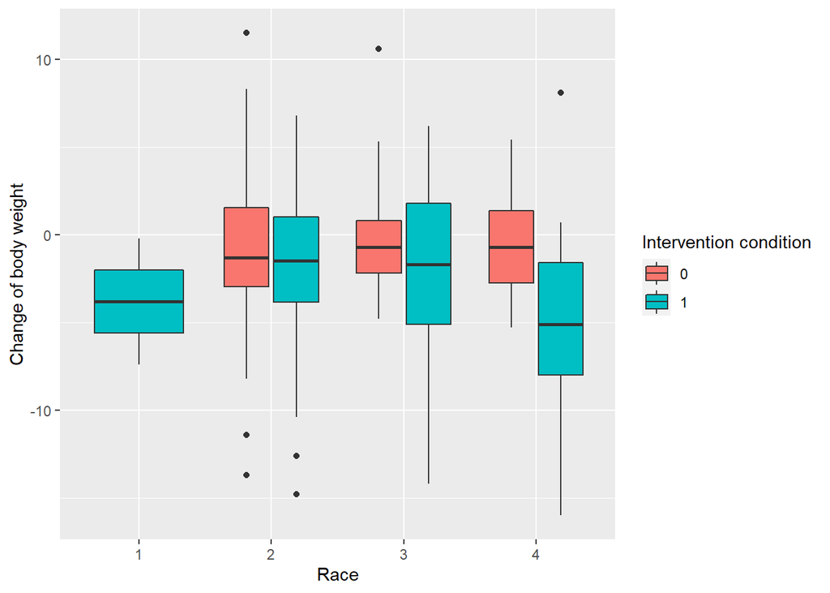

```r
## Race
boxplot_Race <- ggplot(data = clean_WL_data,
                  mapping = aes (x = as.factor(race), y = (wgt_final - wgt_base), fill = as.factor(tx)))+
  geom_boxplot() +
  xlab("Race") +
  ylab("Change of body weight") +
  scale_fill_discrete("Intervention condition")
plot(boxplot_Race)
```

```r
num_As <- sum(clean_WL_data$race == 1)
num_AA <- sum(clean_WL_data$race == 2)
num_HL <- sum(clean_WL_data$race == 3)
num_NHW <- sum(clean_WL_data$race == 4)
print(sprintf("Number of Asian subjects = %d, African American = %d, Hispanic/Latino = %d, Non-Hispanic white = %d", num_As, num_AA, num_HL, num_NHW))
```

```
## [1] "Number of Asian subjects = 2, African American = 113, Hispanic/Latino = 22, Non-Hispanic white = 29"
```

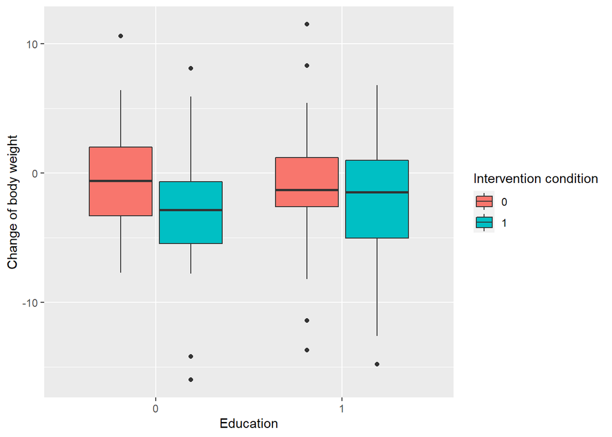

```r
## Education
boxplot_Education <- ggplot(data = clean_WL_data,
                  mapping = aes (x = as.factor(education), y = (wgt_final - wgt_base), fill = as.factor(tx)))+
  geom_boxplot() +
  xlab("Education") +
  ylab("Change of body weight") +
  scale_fill_discrete("Intervention condition")
plot(boxplot_Education)
```

```r
num_unedu <- sum(clean_WL_data$education == 0)
num_edu <- sum(clean_WL_data$education == 1)
print(sprintf("Number of subjects with education less than 12 yrs. = %d, more than 12 yrs. = %d", num_unedu, num_edu))
```

```
## [1] "Number of subjects with education less than 12 yrs. = 51, more than 12 yrs. = 115"
```

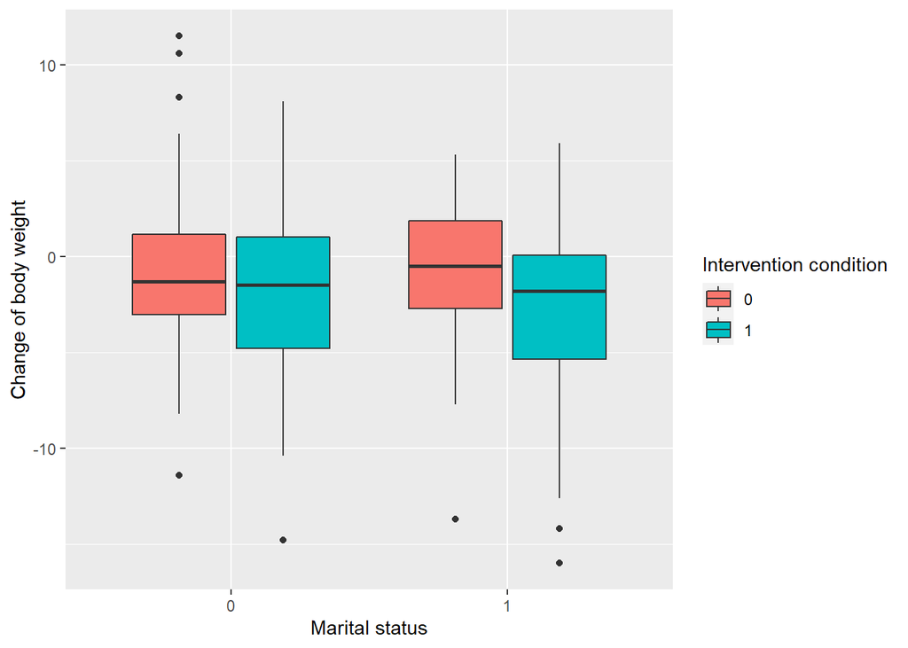

```r
## Marital status
boxplot_Marital <- ggplot(data = clean_WL_data,
                  mapping = aes (x = as.factor(married), y = (wgt_final - wgt_base), fill = as.factor(tx)))+
  geom_boxplot() +
  xlab("Marital status") +
  ylab("Change of body weight") +
  scale_fill_discrete("Intervention condition")
plot(boxplot_Marital)
```

```r
num_unmar <- sum(clean_WL_data$married == 0)
num_mar <- sum(clean_WL_data$married == 1)
print(sprintf("Number of non-married subjects = %d, married subjects = %d", num_unmar, num_mar))
```

```
## [1] "Number of non-married subjects = 92, married subjects = 74"
```

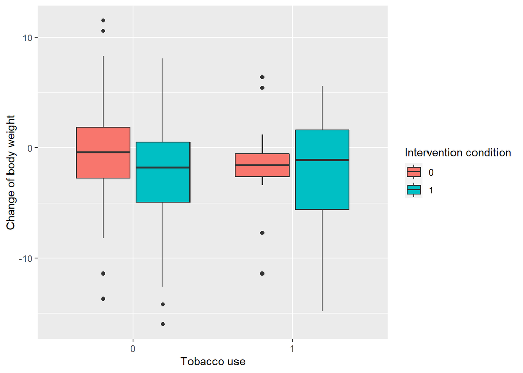

```r
## Tobacco use
boxplot_Tabacco <- ggplot(data = clean_WL_data,
                  mapping = aes (x = as.factor(smoker), y = (wgt_final - wgt_base), fill = as.factor(tx)))+
  geom_boxplot() +
  xlab("Tobacco use") +
  ylab("Change of body weight") +
  scale_fill_discrete("Intervention condition")
plot(boxplot_Tabacco)
```

```r
num_nonsmo <- sum(clean_WL_data$smoker == 0)
num_smo <- sum(clean_WL_data$smoker == 1)
print(sprintf("Number of non-smoker = %d, smoker = %d", num_nonsmo, num_smo))
```

```
## [1] "Number of non-smoker = 137, smoker = 29"
```

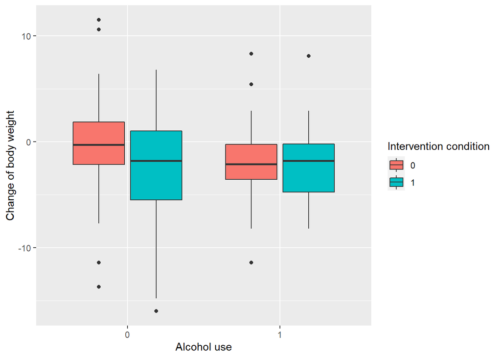

```r
## Alcohol use
boxplot_Alcohol <- ggplot(data = clean_WL_data,
                  mapping = aes (x = as.factor(drinker), y = (wgt_final - wgt_base), fill = as.factor(tx)))+
  geom_boxplot() +
  xlab("Alcohol use") +
  ylab("Change of body weight") +
  scale_fill_discrete("Intervention condition")
plot(boxplot_Alcohol)
```

```r
num_nondrk <- sum(clean_WL_data$drinker == 0)
num_drk <- sum(clean_WL_data$drinker == 1)
print(sprintf("Number of non-drinker = %d, drinker = %d", num_nondrk, num_drk))
```

```
## [1] "Number of non-drinker = 116, drinker = 50"
```

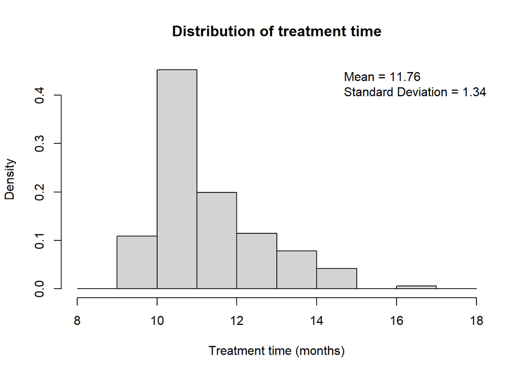

```r
## 2.2.2 Continuous Covariates

## Time since randomization to final weight
# Histogram
month <- (clean_WL_data$month)
hist(month,
     main = "Distribution of treatment time",
     xlab = "Treatment time (months)",
     freq = FALSE,
     breaks = seq(8, 18, 1))
legend(
  "topright",
  legend = c(paste("Mean =", round(mean(month), 2)),
             paste("Standard Deviation =", round(sd(month), 2))),
  cex = 1, bty = "n"
)
```

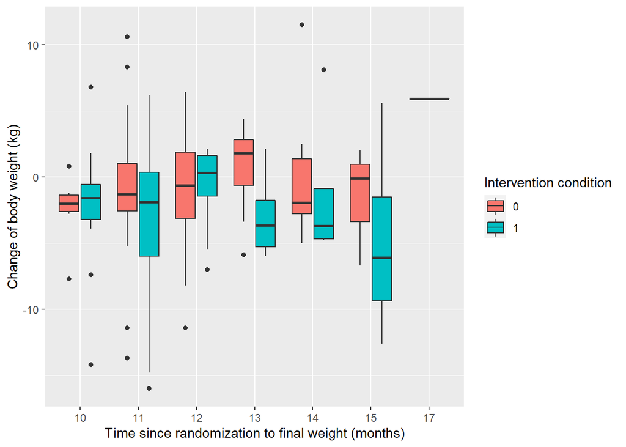

```r
# Boxplot
boxplot_Time <- ggplot(data = clean_WL_data,
                  mapping = aes (x = as.factor(month), y = (wgt_final - wgt_base), fill = as.factor(tx)))+
  geom_boxplot() +
  xlab("Time since randomization to final weight (months)") +
  ylab("Change of body weight (kg)") +
  scale_fill_discrete("Intervention condition")
plot(boxplot_Time)
```

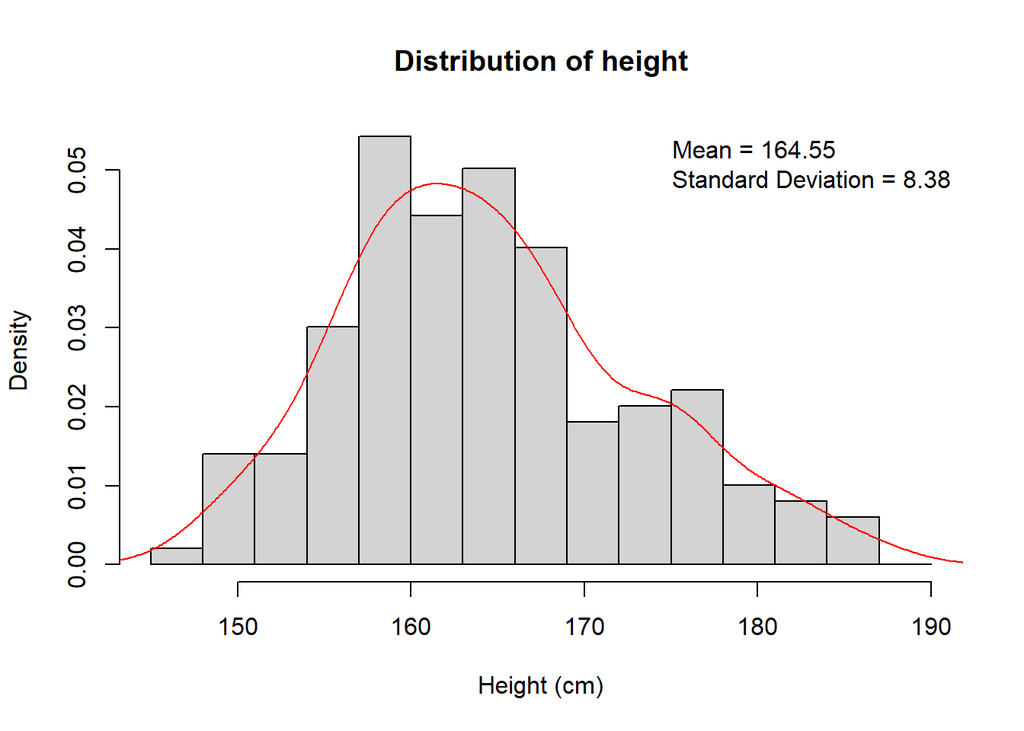

```r
## Height
# Histogram
hgt <- (clean_WL_data$height)
hist(hgt,
     main = "Distribution of height",
     xlab = "Height (cm)",
     freq = FALSE,
     breaks = seq(145, 190, 3))

lines(
  x = density(x = hgt),
  col = "red"
)

legend(
  "topright",
  legend = c(paste("Mean =", round(mean(hgt), 2)),
             paste("Standard Deviation =", round(sd(hgt), 2))),
  cex = 1, bty = "n"
)
```

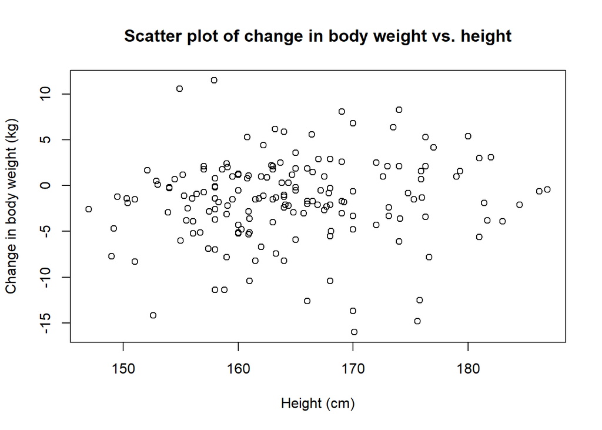

```r
# scatter plot
plot(hgt, (clean_WL_data$wgt_final - clean_WL_data$wgt_base),
     main = "Scatter plot of change in body weight vs. height",
     xlab = "Height (cm)",
     ylab = "Change in body weight (kg)")
```

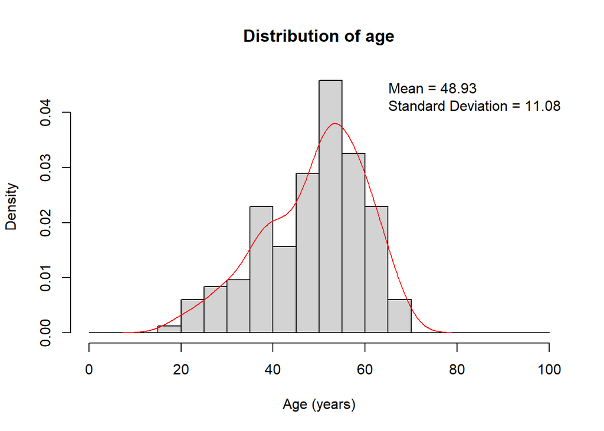

```r
## Age
# Histogram
age <- clean_WL_data$age
hist(age,
     main = "Distribution of age",
     xlab = "Age (years)",
     freq = FALSE,
     breaks = seq(0, 100, 5))
lines(
  x = density(x = age),
  col = "red"
)

legend(
  "topright",
  legend = c(paste("Mean =", round(mean(age), 2)),
             paste("Standard Deviation =", round(sd(age), 2))),
  cex = 1, bty = "n"
)
```

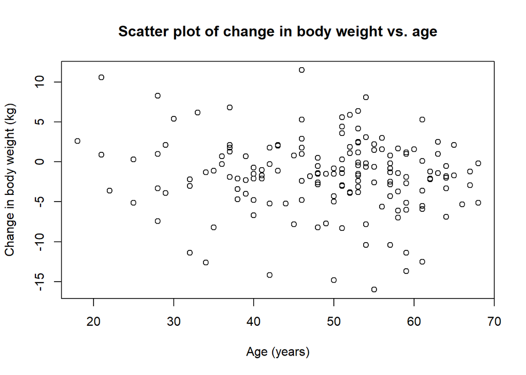

```r
# Scatter plot
plot(age, (clean_WL_data$wgt_final - clean_WL_data$wgt_base),
     main = "Scatter plot of change in body weight vs. age",
     xlab = "Age (years)",
     ylab = "Change in body weight (kg)")
```

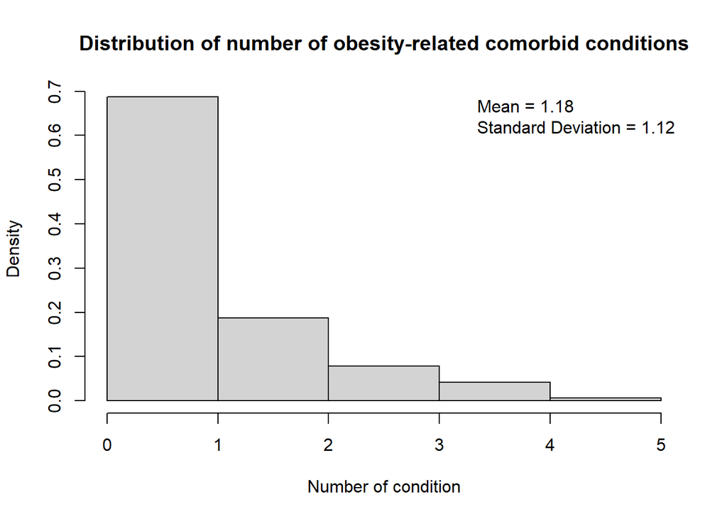

```r
## Number of obesity-related comorbid conditions

# Histogram
cmb <- (clean_WL_data$comorbid)
hist(cmb,
     main = "Distribution of number of obesity-related comorbid conditions",
     xlab = "Number of condition",
     freq = FALSE,
     breaks = seq(0, 5, 1))

legend(
  "topright",
  legend = c(paste("Mean =", round(mean(cmb), 2)),
             paste("Standard Deviation =", round(sd(cmb), 2))),
  cex = 1, bty = "n"
)
```

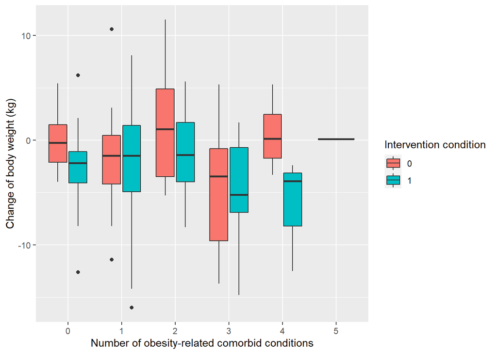

```r
# Boxplot
boxplot_cmb <- ggplot(data = clean_WL_data,
                  mapping = aes (x = as.factor(comorbid), y = (wgt_final - wgt_base), fill = as.factor(tx)))+
  geom_boxplot() +
  xlab("Number of obesity-related comorbid conditions") +
  ylab("Change of body weight (kg)") +
  scale_fill_discrete("Intervention condition")
plot(boxplot_cmb)
```

> 3. Point estimates and Confidence intervals

> Point estimates and confidence intervals for continuous variables including change in body weight in control and intervention group, height, and age of subjects following normal distribution with unknown population variance. Also, 95% confidence intervals, sample mean, sample standard deviation, and sample size for all variables are obtained. On the other hand, the normal approximation is not valid for the treatment time and number of obesity related comorbid conditions so that bootstrap method was applied to construct the confidence intervals.

> Point estimates and confidence intervals for catagorical variables were obtained as well. All the catagorical varibles follow multinomial distribution, and the exact simultaneous 95% confidence intervals were obtained by sisong-glaz method.

```r
###### 3. Point estimates and confidence intervals------------------------------
### 3.1 Point estimates and CI for Continuous variables

## Change in body weight (kg) in control group
# Mean
X_bar_ctrl <-  mean(ctrl_wgt_loss)
print(sprintf("Mean of Change in body weight (control) = %f", X_bar_ctrl))
```

```
## [1] "Mean of Change in body weight (control) = -0.794444"
```

```r
# SD
sd_ctrl <- sd(ctrl_wgt_loss)
print(sprintf("SD of Change in body weight (control) = %f", sd_ctrl))
```

```
## [1] "SD of Change in body weight (control) = 4.140872"
```

```r
# CI95 for mean (normal approx. is valid)
n_ctrl <- length(ctrl_wgt_loss)
t_ctrl <- qt(p = 0.05/2, df = (n_ctrl-1))
L_ctrl <- X_bar_ctrl + t_ctrl * (sd_ctrl/sqrt(n_ctrl))
U_ctrl <- X_bar_ctrl - t_ctrl * (sd_ctrl/sqrt(n_ctrl))
print(sprintf("CI95 for mean = [%f, %f]", L_ctrl, U_ctrl))
```

```
## [1] "CI95 for mean = [-1.661733, 0.072844]"
```

```r
# Median
Med_ctrl <- median(ctrl_wgt_loss)
print(sprintf("Median of Change in body weight (control) = %f", Med_ctrl))
```

```
## [1] "Median of Change in body weight (control) = -0.900000"
```

```r
## Change in body weight (kg) in intervention group
# Mean
X_bar_int <-  mean(int_wgt_loss)
print(sprintf("Mean of Change in body weight (intervention) = %f", X_bar_int))
```

```
## [1] "Mean of Change in body weight (intervention) = -2.480263"
```

```r
# SD
s_int <- sd(int_wgt_loss)
print(sprintf("SD of Change in body weight (intervention) = %f", s_int))
```

```
## [1] "SD of Change in body weight (intervention) = 4.933559"
```

```r
# CI95 for mean (normal approx. is valid)
n_int <- length(int_wgt_loss)
t_int <- qt(p = 0.05/2, df = (n_int-1))
L_int <- X_bar_int + t_int * (s_int/sqrt(n_int))
U_int <- X_bar_int - t_int * (s_int/sqrt(n_int))
print(sprintf("CI95 for mean = [%f, %f]", L_int, U_int))
```

```
## [1] "CI95 for mean = [-3.607630, -1.352897]"
```

```r
# Median
Med_int <- median(int_wgt_loss)
print(sprintf("Median of Change in body weight (control) = %f", Med_int))
```

```
## [1] "Median of Change in body weight (control) = -1.800000"
```

```r
## Height
# Mean
X_bar_height <-  mean(hgt)
print(sprintf("Mean of height = %f", X_bar_height))
```

```
## [1] "Mean of height = 164.549398"
```

```r
# SD
s_height <- sd(hgt)
print(sprintf("SD of height = %f", s_height))
```

```
## [1] "SD of height = 8.375265"
```

```r
# CI95 for mean (normal approx. is valid)
n_height <- length(hgt)
t_height <- qt(p = 0.05/2, df = (n_height-1))
L_height <- X_bar_height + t_height * (s_height/sqrt(n_height))
U_height <- X_bar_height - t_height * (s_height/sqrt(n_height))
print(sprintf("CI95 for mean = [%f, %f]", L_height, U_height))
```

```
## [1] "CI95 for mean = [163.265916, 165.832879]"
```

```r
# Median
Med_height <- median(hgt)
print(sprintf("Median of height = %f", Med_height))
```

```
## [1] "Median of height = 163.750000"
```

```r
## Age
# Mean
X_bar_age <-  mean(age)
print(sprintf("Mean of age = %f", X_bar_age))
```

```
## [1] "Mean of age = 48.927711"
```

```r
# SD
s_age <- sd(age)
print(sprintf("SD of age = %f", s_age))
```

```
## [1] "SD of age = 11.081826"
```

```r
# CI95 for mean (normal approx. is valid)
n_age <- length(age)
t_age <- qt(p = 0.05/2, df = (n_age-1))
L_age <- X_bar_age + t_age * (s_age/sqrt(n_age))
U_age <- X_bar_age - t_age * (s_age/sqrt(n_age))
print(sprintf("CI95 for mean = [%f, %f]", L_age, U_age))
```

```
## [1] "CI95 for mean = [47.229458, 50.625964]"
```

```r
# Median
Med_age <- median(age)
print(sprintf("Median of age = %f", Med_age))
```

```
## [1] "Median of age = 51.000000"
```

```r
## Treatment time
# Mean
X_bar_treatime <- mean(month)
print(sprintf("Mean of treatment time = %f", X_bar_treatime))
```

```
## [1] "Mean of treatment time = 11.759036"
```

```r
# SD
s_treatime <- sd(month)
print(sprintf("SD of treatment time = %f", s_treatime))
```

```
## [1] "SD of treatment time = 1.340198"
```

```r
# CI95 for mean (bootstrap)
set.seed(1996)
mean.month.bootstrap <- sapply(
  X = 1:2000,
  FUN = function(a){
    mean(
      x = sample(
        x = (month),
        size = length(month),
        replace = TRUE
      )
    )
  }
)
head(mean.month.bootstrap)
```

```
## [1] 11.70482 11.83735 11.66265 11.57229 11.62651 11.53012
```

```r
# A 95% bootstrap CI for treatment time
# 2.5th and 97.5th percentiles
Low_treatime <- quantile(x = mean.month.bootstrap, probs = 0.025)
Upper_treatime <- quantile(x = mean.month.bootstrap, probs = 0.975)
print(sprintf("CI95 for mean = [%f, %f]", Low_treatime, Upper_treatime))
```

```
## [1] "CI95 for mean = [11.554217, 11.975904]"
```

```r
# Median
Med_treatime <- median(month)
print(sprintf("Median of treatment time = %f", Med_treatime))
```

```
## [1] "Median of treatment time = 11.000000"
```

```r
## Number of obesity-related comorbid conditions
# Mean
X_bar_comorbid <- mean(cmb)
print(sprintf("Mean of number of obesity-related comorbid conditions = %f", X_bar_comorbid))
```

```
## [1] "Mean of number of obesity-related comorbid conditions = 1.180723"
```

```r
# SD
s_comorbid <- sd(cmb)
print(sprintf("SD of number of obesity-related comorbid conditions = %f", s_comorbid))
```

```
## [1] "SD of number of obesity-related comorbid conditions = 1.124327"
```

```r
# CI95 for mean (bootstrap)
set.seed(1996)
mean.cmb.bootstrap <- sapply(
  X = 1:2000,
  FUN = function(a){
    mean(
      x = sample(
        x = (cmb),
        size = length(cmb),
        replace = TRUE
      )
    )
  }
)
head(mean.cmb.bootstrap)
```

```
## [1] 1.204819 1.228916 1.120482 1.066265 1.198795 1.144578
```

```r
# A 95% bootstrap CI for number of obesity-related comorbid conditions
# 2.5th and 97.5th percentiles
Low_comorbid <- quantile(x = mean.cmb.bootstrap, probs = 0.025)
Upper_comorbid <- quantile(x = mean.cmb.bootstrap, probs = 0.975)
print(sprintf("CI95 for mean = [%f, %f]", Low_comorbid, Upper_comorbid))
```

```
## [1] "CI95 for mean = [1.012048, 1.361446]"
```

```r
# Median
Med_comorbid <- median(cmb)
print(sprintf("Median of number of obesity-related comorbid conditions = %f", Med_comorbid))
```

```
## [1] "Median of number of obesity-related comorbid conditions = 1.000000"
```

```r
### 3.2 Point estimates and CI for categorical variables
## Clinical sites
print(MultinomCI(c(num_s1, num_s2, num_s3, num_s4, num_s5), conf.level = 0.95))
```

```
##            est     lwr.ci    upr.ci
## [1,] 0.2289157 0.15662651 0.3110767
## [2,] 0.2650602 0.19277108 0.3472212
## [3,] 0.2409639 0.16867470 0.3231248
## [4,] 0.1204819 0.04819277 0.2026429
## [5,] 0.1445783 0.07228916 0.2267393
```

```r
## Gender
print(MultinomCI(c(num_male, num_female), conf.level = 0.95))
```

```
##            est    lwr.ci    upr.ci
## [1,] 0.1566265 0.1084337 0.2132829
## [2,] 0.8433735 0.7951807 0.9000299
```

```r
## Race
print(MultinomCI(c(num_As, num_AA, num_HL, num_NHW), conf.level = 0.95))
```

```
##             est     lwr.ci     upr.ci
## [1,] 0.01204819 0.00000000 0.08405183
## [2,] 0.68072289 0.61445783 0.75272653
## [3,] 0.13253012 0.06626506 0.20453376
## [4,] 0.17469880 0.10843373 0.24670243
```

```r
## Education
print(MultinomCI(c(num_unedu, num_edu), conf.level = 0.95))
```

```
##            est    lwr.ci    upr.ci
## [1,] 0.3072289 0.2409639 0.3808160
## [2,] 0.6927711 0.6265060 0.7663582
```

```r
## Marital status
print(MultinomCI(c(num_unmar, num_mar), conf.level = 0.95))
```

```
##            est    lwr.ci    upr.ci
## [1,] 0.5542169 0.4819277 0.6358363
## [2,] 0.4457831 0.3734940 0.5274026
```

```r
## Tobacco use
print(MultinomCI(c(num_nonsmo, num_smo), conf.level = 0.95))
```

```
##            est    lwr.ci    upr.ci
## [1,] 0.8253012 0.7710843 0.8812841
## [2,] 0.1746988 0.1204819 0.2306817
```

```r
## Alcohol use
print(MultinomCI(c(num_nondrk, num_drk), conf.level = 0.95))
```

```
##            est    lwr.ci    upr.ci
## [1,] 0.6987952 0.6325301 0.7714176
## [2,] 0.3012048 0.2349398 0.3738272
```

> 4. Hypothesis Testing

> The main objective for this study is to statistically evaluate the effectiveness of the mderate-intensity weight loss program. Whether the mean of change in body weight for the intervention group is lower than control group will be tested. According to previous analysis, normal approximation is valid for change in body weight for both control and intervention group. Before the hypothesis testing, Barlett’s test was conducted to check whether standard deviations of two groups are significantly different. The p-value obtained from the Barlett’s test is 0.114, indicating that standard deviations of two groups are NOT significantly different. Next, we will conduct one-sided twp-sample t-test with unknwon and equal variance.

> The Null hypothesis: Mean of change in body weight of intervention group is NOT significantly different fron control group

> According to the p-value = 0.0089 < 0.05, we reject the null hypothesis and conclude that mean of chane in bpdy weight of intervention group is significantly less than control group. In other words, the moderate-intensity weight-loss treatment is significantly effective compared with the control group.

```r
# Bartlet's test for checking whether two variances are equal
print(bartlett.test(list(int_wgt_loss, ctrl_wgt_loss)))
```

```
##
##  Bartlett test of homogeneity of variances
##
## data:  list(int_wgt_loss, ctrl_wgt_loss)
## Bartlett's K-squared = 2.4942, df = 1, p-value = 0.1143
```

```r
# p-value = 0.1143 > 0.05, indicating the variances are the same.

# pooled estimate of the variance
n1_int <- length(int_wgt_loss)
n2_ctrl <- length(ctrl_wgt_loss)
sp_sq <- ((n1_int-1)*var(int_wgt_loss) + (n2_ctrl-1)*var(ctrl_wgt_loss))/(n1_int + n2_ctrl -2)
# Test statistic
x_bar1_int <- mean(int_wgt_loss)
x_bar2_ctrl <- mean(ctrl_wgt_loss)
test_sta_HypoTest  = (x_bar1_int - x_bar2_ctrl)/sqrt(sp_sq * (1/n1_int + 1/n2_ctrl))
print(sprintf("Test statistic under H0 = %f", test_sta_HypoTest))
```

```
## [1] "Test statistic under H0 = -2.393772"
```

```r
# one-sided p-value
p_value_HypoTest <- pt(test_sta_HypoTest, df = (n1_int + n2_ctrl - 2))
print(sprintf("p-value = %f", p_value_HypoTest))
```

```
## [1] "p-value = 0.008903"
```

> 5. Linear Model

> According section2, change in body weight follows normal distribution so a linear regression model will be built to predict the amount of body weight change for participants in the weight-loss program. Data show that the adjusted R^2 = 0.01562, the overall p-value for the model is 0.3095, indicating the weak relationship between our predictors and the responsive varibales, so the linear model has weak predictive abilit for the change in body weight.

> A better model can be obtained by removal of unrelated predictors, since more covariates included, more dependednt the model is on this specific dataset. Next, only clinically and intuitively relavant variables including intervention condition, age, gender, tabacco and alcohol use, treatment time and number of comorbid conditions would be used for establishing the linear model. As a result, the model b has the greatest adjusted R^2 while keeping the overall p-value less than 0.05, indicating a significant relationship between the selected predictors and responive varaibles, so the factors intervention condition and age is potentially preferred. In addition, the estimate for the regression coefficient of intervention condition implied that subjects in moderate-intensity program are expected to lose 1.67kg more than control group, which is consistent with the result obtained from the Hypothesis testing.

```r
library(dplyr)
###### 5. Linear Model----------------------------------------------------------
### 5.1 Model fitting
# Change categorical variables to factor
fatrd_WL_data <- clean_WL_data %>%
  mutate(
    site = as.factor(site),
    race = as.factor(race),
    education = as.factor(education),
    gender = as.factor(gender),
    married = as.factor(married),
    smoker = as.factor(smoker),
    drinker = as.factor(drinker),
    tx = as.factor(tx)
  )

# Fit to a initial linear model involving all the variables
WeightLoss_model <- lm((wgt_final-wgt_base) ~
                         site +
                         race +
                         age +
                         education +
                         gender +
                         married +
                         smoker +
                         drinker +
                         month +
                         tx +
                         height +
                         comorbid,
                       data = fatrd_WL_data,
                       x = TRUE)

# Estimate regression coefficients
print(summary(WeightLoss_model))
```

```
##
## Call:
## lm(formula = (wgt_final - wgt_base) ~ site + race + age + education +
##     gender + married + smoker + drinker + month + tx + height +
##     comorbid, data = fatrd_WL_data, x = TRUE)
##
## Residuals:
##      Min       1Q   Median       3Q      Max
## -12.4290  -2.5679   0.1968   2.6388  11.6978
##
## Coefficients:
##              Estimate Std. Error t value Pr(>|t|)
## (Intercept) -14.80240   11.59641  -1.276   0.2038
## site2         0.45828    1.09244   0.420   0.6755
## site3         1.12668    1.17990   0.955   0.3412
## site4        -1.13503    1.57126  -0.722   0.4712
## site5         2.54613    1.29693   1.963   0.0515 .
## race2        -0.12640    3.39339  -0.037   0.9703
## race3         0.95103    3.45763   0.275   0.7837
## race4        -0.12072    3.47970  -0.035   0.9724
## age          -0.02351    0.03681  -0.639   0.5240
## education1   -0.30642    0.83055  -0.369   0.7127
## gender1       0.51153    1.40348   0.364   0.7160
## married1     -0.29066    0.76735  -0.379   0.7054
## smoker1      -0.57277    1.01873  -0.562   0.5748
## drinker1     -0.54979    0.86286  -0.637   0.5250
## month         0.19248    0.30739   0.626   0.5322
## tx1          -1.78167    0.73677  -2.418   0.0168 *
## height        0.07664    0.05630   1.361   0.1755
## comorbid     -0.11772    0.35263  -0.334   0.7390
## ---
## Signif. codes:  0 '***' 0.001 '**' 0.01 '*' 0.05 '.' 0.1 ' ' 1
##
## Residual standard error: 4.549 on 148 degrees of freedom
## Multiple R-squared:  0.117,  Adjusted R-squared:  0.01562
## F-statistic: 1.154 on 17 and 148 DF,  p-value: 0.3095
```

```r
print(confint(object = WeightLoss_model, level = 0.95), digits=2)
```

```
##               2.5 % 97.5 %
## (Intercept) -37.718  8.114
## site2        -1.701  2.617
## site3        -1.205  3.458
## site4        -4.240  1.970
## site5        -0.017  5.109
## race2        -6.832  6.579
## race3        -5.882  7.784
## race4        -6.997  6.756
## age          -0.096  0.049
## education1   -1.948  1.335
## gender1      -2.262  3.285
## married1     -1.807  1.226
## smoker1      -2.586  1.440
## drinker1     -2.255  1.155
## month        -0.415  0.800
## tx1          -3.238 -0.326
## height       -0.035  0.188
## comorbid     -0.815  0.579
```

```r
# Compare to simpler linear models
# Model a
model_a <- lm((wgt_final-wgt_base) ~ tx,
         data = fatrd_WL_data,
         x = TRUE)
print(summary(model_a))
```

```
##
## Call:
## lm(formula = (wgt_final - wgt_base) ~ tx, data = fatrd_WL_data,
##     x = TRUE)
##
## Residuals:
##      Min       1Q   Median       3Q      Max
## -13.5197  -2.1912   0.2374   2.7909  12.2944
##
## Coefficients:
##             Estimate Std. Error t value Pr(>|t|)
## (Intercept)  -0.7944     0.4765  -1.667   0.0974 .
## tx1          -1.6858     0.7043  -2.394   0.0178 *
## ---
## Signif. codes:  0 '***' 0.001 '**' 0.01 '*' 0.05 '.' 0.1 ' ' 1
##
## Residual standard error: 4.521 on 164 degrees of freedom
## Multiple R-squared:  0.03376,    Adjusted R-squared:  0.02787
## F-statistic:  5.73 on 1 and 164 DF,  p-value: 0.01781
```

```r
# Model b
model_b <- lm((wgt_final-wgt_base) ~ tx + age,
                   data = fatrd_WL_data,
                   x = TRUE)
print(summary(model_b))
```

```
##
## Call:
## lm(formula = (wgt_final - wgt_base) ~ tx + age, data = fatrd_WL_data,
##     x = TRUE)
##
## Residuals:
##      Min       1Q   Median       3Q      Max
## -13.2364  -2.1950   0.2564   2.5743  12.1609
##
## Coefficients:
##             Estimate Std. Error t value Pr(>|t|)
## (Intercept)  1.54985    1.61444   0.960   0.3385
## tx1         -1.67008    0.70154  -2.381   0.0184 *
## age         -0.04806    0.03164  -1.519   0.1306
## ---
## Signif. codes:  0 '***' 0.001 '**' 0.01 '*' 0.05 '.' 0.1 ' ' 1
##
## Residual standard error: 4.503 on 163 degrees of freedom
## Multiple R-squared:  0.04725,    Adjusted R-squared:  0.03556
## F-statistic: 4.042 on 2 and 163 DF,  p-value: 0.01935
```

```r
# Model c
model_c <- lm((wgt_final-wgt_base) ~ tx + age + gender,
                   data = fatrd_WL_data,
                   x = TRUE)
print(summary(model_c))
```

```
##
## Call:
## lm(formula = (wgt_final - wgt_base) ~ tx + age + gender, data = fatrd_WL_data,
##     x = TRUE)
##
## Residuals:
##      Min       1Q   Median       3Q      Max
## -13.2385  -2.1946   0.2568   2.5747  12.1613
##
## Coefficients:
##             Estimate Std. Error t value Pr(>|t|)
## (Intercept)  1.55203    1.82530   0.850   0.3964
## tx1         -1.67009    0.70370  -2.373   0.0188 *
## age         -0.04806    0.03174  -1.514   0.1319
## gender1     -0.00250    0.96469  -0.003   0.9979
## ---
## Signif. codes:  0 '***' 0.001 '**' 0.01 '*' 0.05 '.' 0.1 ' ' 1
##
## Residual standard error: 4.517 on 162 degrees of freedom
## Multiple R-squared:  0.04725,    Adjusted R-squared:  0.02961
## F-statistic: 2.678 on 3 and 162 DF,  p-value: 0.04888
```

```r
# Model d
model_d <- lm((wgt_final-wgt_base) ~ tx + age + gender + smoker,
                   data = fatrd_WL_data,
                   x = TRUE)
print(summary(model_d))
```

```
##
## Call:
## lm(formula = (wgt_final - wgt_base) ~ tx + age + gender + smoker,
##     data = fatrd_WL_data, x = TRUE)
##
## Residuals:
##      Min       1Q   Median       3Q      Max
## -13.4103  -2.2403   0.3082   2.6288  12.1101
##
## Coefficients:
##             Estimate Std. Error t value Pr(>|t|)
## (Intercept)  1.69133    1.86042   0.909   0.3646
## tx1         -1.67327    0.70555  -2.372   0.0189 *
## age         -0.04741    0.03186  -1.488   0.1386
## gender1     -0.12039    1.00790  -0.119   0.9051
## smoker1     -0.40144    0.96592  -0.416   0.6783
## ---
## Signif. codes:  0 '***' 0.001 '**' 0.01 '*' 0.05 '.' 0.1 ' ' 1
##
## Residual standard error: 4.528 on 161 degrees of freedom
## Multiple R-squared:  0.04827,    Adjusted R-squared:  0.02463
## F-statistic: 2.041 on 4 and 161 DF,  p-value: 0.09104
```

```r
# Model e
model_e <- lm((wgt_final-wgt_base) ~ tx + age + gender + smoker + drinker,
                   data = fatrd_WL_data,
                   x = TRUE)
print(summary(model_e))
```

```
##
## Call:
## lm(formula = (wgt_final - wgt_base) ~ tx + age + gender + smoker +
##     drinker, data = fatrd_WL_data, x = TRUE)
##
## Residuals:
##      Min       1Q   Median       3Q      Max
## -13.6308  -2.2828   0.5142   2.5298  11.9851
##
## Coefficients:
##             Estimate Std. Error t value Pr(>|t|)
## (Intercept)  2.00330    1.93998   1.033   0.3033
## tx1         -1.67179    0.70701  -2.365   0.0192 *
## age         -0.04910    0.03206  -1.532   0.1275
## gender1     -0.22963    1.02732  -0.224   0.8234
## smoker1     -0.40424    0.96793  -0.418   0.6768
## drinker1    -0.45608    0.78466  -0.581   0.5619
## ---
## Signif. codes:  0 '***' 0.001 '**' 0.01 '*' 0.05 '.' 0.1 ' ' 1
##
## Residual standard error: 4.538 on 160 degrees of freedom
## Multiple R-squared:  0.05028,    Adjusted R-squared:  0.0206
## F-statistic: 1.694 on 5 and 160 DF,  p-value: 0.1389
```

```r
# Model f
model_f <- lm((wgt_final-wgt_base) ~ tx + age + gender + smoker + drinker + month,
                   data = fatrd_WL_data,
                   x = TRUE)
print(summary(model_f))
```

```
##
## Call:
## lm(formula = (wgt_final - wgt_base) ~ tx + age + gender + smoker +
##     drinker + month, data = fatrd_WL_data, x = TRUE)
##
## Residuals:
##      Min       1Q   Median       3Q      Max
## -13.3887  -2.1276   0.5607   2.6965  11.4585
##
## Coefficients:
##             Estimate Std. Error t value Pr(>|t|)
## (Intercept) -1.13360    3.77682  -0.300   0.7645
## tx1         -1.63599    0.70811  -2.310   0.0222 *
## age         -0.04874    0.03206  -1.520   0.1305
## gender1     -0.19608    1.02810  -0.191   0.8490
## smoker1     -0.33533    0.97073  -0.345   0.7302
## drinker1    -0.36469    0.79047  -0.461   0.6452
## month        0.25809    0.26659   0.968   0.3345
## ---
## Signif. codes:  0 '***' 0.001 '**' 0.01 '*' 0.05 '.' 0.1 ' ' 1
##
## Residual standard error: 4.538 on 159 degrees of freedom
## Multiple R-squared:  0.05584,    Adjusted R-squared:  0.02021
## F-statistic: 1.567 on 6 and 159 DF,  p-value: 0.16
```

```r
# Model g
model_g <- lm((wgt_final-wgt_base) ~ tx + age + gender + smoker + drinker + month + comorbid,
                   data = fatrd_WL_data,
                   x = TRUE)
print(summary(model_g))
```

```
##
## Call:
## lm(formula = (wgt_final - wgt_base) ~ tx + age + gender + smoker +
##     drinker + month + comorbid, data = fatrd_WL_data, x = TRUE)
##
## Residuals:
##      Min       1Q   Median       3Q      Max
## -13.5203  -2.1870   0.4971   2.7835  11.6207
##
## Coefficients:
##             Estimate Std. Error t value Pr(>|t|)
## (Intercept) -1.15676    3.78557  -0.306   0.7603
## tx1         -1.60090    0.71273  -2.246   0.0261 *
## age         -0.04357    0.03355  -1.299   0.1959
## gender1     -0.23193    1.03259  -0.225   0.8226
## smoker1     -0.31190    0.97390  -0.320   0.7492
## drinker1    -0.44278    0.80557  -0.550   0.5833
## month        0.25959    0.26721   0.972   0.3328
## comorbid    -0.18094    0.33804  -0.535   0.5932
## ---
## Signif. codes:  0 '***' 0.001 '**' 0.01 '*' 0.05 '.' 0.1 ' ' 1
##
## Residual standard error: 4.549 on 158 degrees of freedom
## Multiple R-squared:  0.05755,    Adjusted R-squared:  0.0158
## F-statistic: 1.378 on 7 and 158 DF,  p-value: 0.218
```

```r
# Model b is selected
print(summary(model_b))
```

```
##
## Call:
## lm(formula = (wgt_final - wgt_base) ~ tx + age, data = fatrd_WL_data,
##     x = TRUE)
##
## Residuals:
##      Min       1Q   Median       3Q      Max
## -13.2364  -2.1950   0.2564   2.5743  12.1609
##
## Coefficients:
##             Estimate Std. Error t value Pr(>|t|)
## (Intercept)  1.54985    1.61444   0.960   0.3385
## tx1         -1.67008    0.70154  -2.381   0.0184 *
## age         -0.04806    0.03164  -1.519   0.1306
## ---
## Signif. codes:  0 '***' 0.001 '**' 0.01 '*' 0.05 '.' 0.1 ' ' 1
##
## Residual standard error: 4.503 on 163 degrees of freedom
## Multiple R-squared:  0.04725,    Adjusted R-squared:  0.03556
## F-statistic: 4.042 on 2 and 163 DF,  p-value: 0.01935
```

```r
print(confint(object = model_b, level = 0.95), digits=2)
```

```
##             2.5 % 97.5 %
## (Intercept) -1.64  4.738
## tx1         -3.06 -0.285
## age         -0.11  0.014
```

> 6. Catagorical Data Analysis

> 6.1 Test for Association

> If we define the criteria for the success of weight-loss as losing at least 5% body weight, he association between the weight-loss success defined above and the intervention condition is examined by a Fisher’s exact test.

> The null hypothesis: There is NO association between the weight-loss success and the intervention condition

> The alternative hypothesis: There is signficant relation between the weight-loss success and the intervention condition

> Since the Fisher’s exact test indicated a p-value = 0.0239 <0.05, so we reject the null hypothesis and conclude that there is significant relation between the weight-loss success and the intervention condition, which is also consistent with the result obtained by the Hypothesis Testing

> 6.2 Logistic Regression

> Next we evaluate the relationship between the intervention condition and the probability of a patient losing at least 5% body weight by using logistic regression. As a result, the regression coefficient for intervention condition indicates a positive correlation between the probability of losing at least 5% body weight and the moderate intensity program, which means that the probability of successful weight-loss for a patient is predicted to be higher in moderate-intensity weight-loss program than control group, which is consistent with previous analytical results.

```r
###### 6. Categorical Data Analysis---------------------------------------------
### 6.1 Test for Association
# Construct contigency table
O.11 <- sum((fatrd_WL_data$tx == 1) & (WL_percent <= -0.05)); print(sprintf("O.11 = %d", O.11))
```

```
## [1] "O.11 = 19"
```

```r
O.12 <- sum((fatrd_WL_data$tx == 1) & (WL_percent > -0.05)); print(sprintf("O.12 = %d", O.12))
```

```
## [1] "O.12 = 57"
```

```r
O.21 <- sum((fatrd_WL_data$tx == 0) & (WL_percent <= -0.05)); print(sprintf("O.21 = %d", O.21))
```

```
## [1] "O.21 = 10"
```

```r
O.22 <- sum((fatrd_WL_data$tx == 0) & (WL_percent > -0.05)); print(sprintf("O.22 = %d", O.22))
```

```
## [1] "O.22 = 80"
```

```r
n1 <- O.11 + O.12
n2 <- O.21 + O.22

# Compute expected values under H0
E.11<- (O.11 + O.21) * n1 / (n1 + n2); print(sprintf("E.11 = %f", E.11))
```

```
## [1] "E.11 = 13.277108"
```

```r
E.12 <- (O.12 + O.22) * n1 / (n1 + n2); print(sprintf("E.12 = %f", E.12))
```

```
## [1] "E.12 = 62.722892"
```

```r
E.21 <- (O.11 + O.21) * n2 / (n1 + n2); print(sprintf("E.21 = %f", E.21))
```

```
## [1] "E.21 = 15.722892"
```

```r
E.22 <- (O.12 + O.22) * n2 / (n1 + n2); print(sprintf("E.22 = %f", E.22))
```

```
## [1] "E.22 = 74.277108"
```

```r
# Fisher's Test
fish_result <- fisher.test(
  matrix(
    data = c(O.11,O.21,O.12,O.22),
    nrow = 2
  )
)
print(fish_result)
```

```
##
##  Fisher's Exact Test for Count Data
##
## data:  matrix(data = c(O.11, O.21, O.12, O.22), nrow = 2)
## p-value = 0.02391
## alternative hypothesis: true odds ratio is not equal to 1
## 95 percent confidence interval:
##  1.077755 6.893325
## sample estimates:
## odds ratio
##   2.650721
```

```r
### 6.2 Logistic Regression
log_model_catag <- glm(as.factor((WL_percent <= -0.05)) ~ tx, family='binomial', data = fatrd_WL_data)
print(summary(log_model_catag))
```

```
##
## Call:
## glm(formula = as.factor((WL_percent <= -0.05)) ~ tx, family = "binomial",
##     data = fatrd_WL_data)
##
## Deviance Residuals:
##     Min       1Q   Median       3Q      Max
## -0.7585  -0.7585  -0.4854  -0.4854   2.0963
##
## Coefficients:
##             Estimate Std. Error z value Pr(>|z|)
## (Intercept)  -2.0794     0.3354  -6.200 5.65e-10 ***
## tx1           0.9808     0.4274   2.295   0.0217 *
## ---
## Signif. codes:  0 '***' 0.001 '**' 0.01 '*' 0.05 '.' 0.1 ' ' 1
##
## (Dispersion parameter for binomial family taken to be 1)
##
##     Null deviance: 153.80  on 165  degrees of freedom
## Residual deviance: 148.26  on 164  degrees of freedom
## AIC: 152.26
##
## Number of Fisher Scoring iterations: 4
```

```r
print(confint(object = log_model_catag, level = 0.95))
```

```
##                  2.5 %    97.5 %
## (Intercept) -2.8006354 -1.471575
## tx1          0.1617863  1.852691
```

> 7. Conslusion

> In a conclusion, we applied multiple statistical tests to evaluate the effectiveness of a moderate behavioral weight loss program in overweight and obese adults in general population by compare it with the weight lose program of low intensity. It’s great that the results of hypothesis testing, the association test and the linear regression model agreed with each other and indicated that the participants in the intervention group could lose more weight than those in the control group. Some variables seemed to affect the effectiveness of the weight loss program, such as age and number of obesity-related comorbid conditions. However, there was no significant relation between these two variables and the weight change after the performing the linear models. It was good that we applied multiple difference to explore the question of interests and we also use graphical and numerical methods to detect their reliability. The weakness would be that we should detect the relation between the weight change and the other variables to find out aspects that may impact on the treatment effectiveness. The findings we had could help researchers and physician to design better and more efficient methods for patients who are suffering the obesity and we could definitely detect the effectiveness of a weight loss program of higher intensity as mentioned above.
> 8. Future plan

> In this study, we compare the effectiveness of the moderate intensity weight loss program with that of the low intensity one. Both the simple association test and the linear regression model showed that the participants of the intervention group could lose more weight that the control group. On the other hand, the difference between the mean weight change of these two groups was just around 1.67 kg which was relatively smaller than participants’ baseline weight. Therefore, we could plan to design a weight lose program of even higher intensity so that we expect to have better effectiveness treatment to help people with obesity to lose weight.

[output not shown]